# Disparities in PPP loans

Sarah Cohen

2020-11-27

## National overview

Only two of these metro divisions saw a pattern of white, non-Hispanic areas getting relatively fewer loans than in Black areas.

## National overview

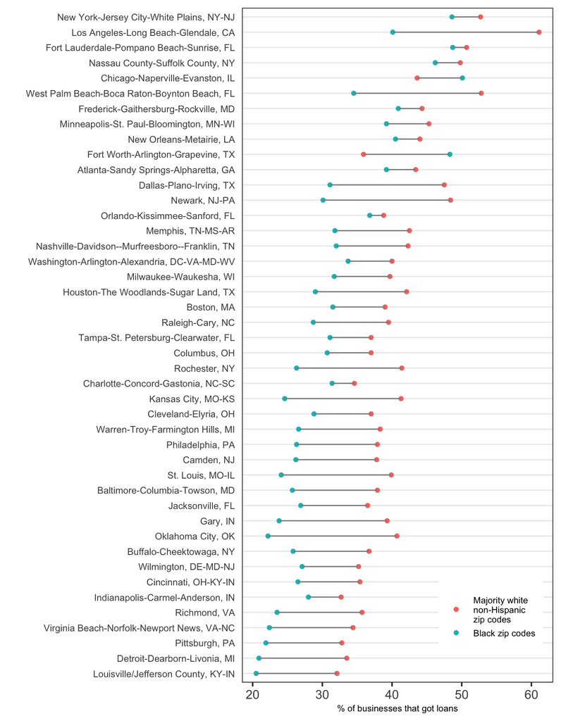

(Includes only metro divisions that had at least 5 zip code areas in each group.)

## Local patterns

I picked out three areas: Philadelphia and Alameda Counties, and New York City, to illustrate the pattern.

### Philadelphia County

Philadelphia, not including their outlying counties, shows a pattern we see in other areas. Here, it’s obvious that some Black areas got a lot of loans compared with the number of businesses found there. But the opposite isn’t true. **All** of the areas that got very few loans are predominantly Black.

(On this map, look for the demographics of the areas that are shaded in the lightest color blue)

[interactive chart not shown]

### New York City

On average, the areas in around New York City had the highest percent of businesses that got loans, but even there, the same pattern holds at higher levels.

[interactive chart not shown]

### Alameda County

Here is how it plays out in a more integrated area – Oakland and Alameda County. Here, primarily Latino areas seem to fare worst in the loans - to - businesses ratio.

[interactive chart not shown]

## Sources & methods

There were four sources for the data above:

- The list of loans released by SBA on Aug. 8, 2020. While there are some errors in the files, and some loans without zip codes, there are no very large areas that appear to be fundamentally miscoded.
- The American Community Survey 5-year data for 2014-2018, extracted from https://socialexplorer.com . This was used to break each Zip Code Tabulation Area into eight mutually exclusive categories:
  1. “No people” - there are zip codes, such as the area around the Washington Monument, or some very industrial areas, that have no people recorded by the survey. We can’t get demographic breakouts for these, even though there may be loans and businesses there.
  2. “Majority White” : More than 50% White non-Hispanic
  3. “No distinct minority” : Although the area is majority-minority, no group makes up at least half of the minority population. This is the same approach taken by the Urban Institute in examining racial and ethnic makeup of neighborhoods.
  4. The remaining groups are “Black”, “Hispanic”, “Asian”, “Native American” and “Other”: One of these groups is chosen if it makes up at least half of the minority population. There are almost no Native American or Other zip code areas in large metros, so you probably won’t see these on the maps. This method was borrowed from an [Urban Institute study](https://www.urban.org/sites/default/files/publication/50906/411358-Understanding-Diverse-Neighborhoods-in-an-Era-of-Demographic-Change.PDF) on the ethnicity of neighborhoods.
- An estimated count of USPS’s business addresses as of December 2019, with Census tracts converted to Zip Codes its Census tract-to-Zip crosswalk’s percent of businesses in each Zip Code.
- The Census’s [Zip Code Business Patterns](https://www.census.gov/programs-surveys/cbp.html) for 2018, which contains the number of for-profit businesses with payrolls. It’s an undercount of the true number of businesses.

For all of the business data, some Zip Codes (from the Postal Service) were converted to Zip Code Tabulation Areas (from the Census) using a [health policy group’s crosswalk](https://udsmapper.org/zip-code-to-zcta-crosswalk/). This happens with large businesses that have their own zip codes, and businesses that use post office boxes rather than street addresses.

### Adjustment to business counts and ratios

There were a lot of anomalies. For example, it was not infrequent to find the number of loans outnumbering the number of businesses that could get loans. In these cases, the USPS data was replaced with the Census business patterns data if it showed more businesses.

If we still ended up with more loans than businesses, the portion of businesses with loans was capped at 100%. This happened in more than 2,000 metro area zip codes, or about 10 percent of all metro area Zip Codes, though only 140 of them had more than 100 loans.

Generally, these adjustments were necessary because the PPP was available to entities that aren’t really recorded at the zip code level in most surveys. For example, a home-based contractor was eligible, as was an Etsy micro-seller. As long as they had a business tax registration, they were eligible for the loans, even if they had no employees or no separate business address. This means that there can be loans in entirely residential areas, or that the post offices used may not relate to the places that the business actually takes place. The other problem is that Zip Codes simply aren’t a very good way to measure demographics or small business loans. They don’t follow any rational boundaries.

### Implications for future use

Unlike work with HMDA and residential redlining, this means that we have no “compared to what” that is reliable across areas. These are rough estimates. (In HMDA, you know the universe of people who applied for loans, so a rate of success is reasonably exact. But here, we don’t really know the universe of businesses that did NOT get loans, even though virtually all were eligible if they were able to get in an application. We’re not worried about rejection rates, but we are worried about the rate of participation and we simply don’t have a good denominator for that.)

It also makes regressions difficult in most areas because we have samples sizes of at most a few hundred zip codes (and often under 100) rather than tens of thousands of applications: We’re studying geographic areas, not loan applications.

We also aren’t using rational demographic lines. Zip code areas are about twice as big as Census tracts, but more importantly don’t follow anything like the same borders. They’re made for the convenience of the Post Office, not for demography. I’ve seen cases where the largest tract in a Zip Code is all-White and high income, but the zip code is among the lowest income in the region.

Comparing businesses rather than residential loans by Zip Code also has a related problem, also related to redlining: We know that minority neighborhoods are more likely to suffer more pollution because they were historically placed in more undesirable, more industrial, areas. That suggests that minority neighborhoods are more mixed into neighborhoods with, say, car repair shops and other quasi-industrial businesses, which can also get loans. In other words, people don’t necessarily work where they live.

#### Caveat: Answers depend on the denominator chosen

Before I mapped USPS businesses into zip codes, which is an approximate exercise, I tried using just the business patterns data. Using that, I got completely different answers – in general, the Black neighborhoods did better than the White ones. However, we need to talk with experts about this and the effects of the source of the number of businesses we started with before the pandemic.